# DSS PML Course project

Dmytro Perepolkin

December 2015

## Background

Using devices such as *Jawbone Up*, *Nike FuelBand*, and *Fitbit* it is now possible to collect a large amount of data about personal activity relatively inexpensively. These type of devices are part of the quantified self movement - a group of enthusiasts who take measurements about themselves regularly to improve their health, to find patterns in their behavior, or because they are tech geeks. One thing that people regularly do is quantify how much of a particular activity they do, but they rarely quantify how well they do it. The goal of this project is to use data from accelerometers on the belt, forearm, arm, and dumbell of 6 participants to identify when they perform barbell lifts correctly and incorrectly in 5 different ways. More information is available from the website [here](http://groupware.les.inf.puc-rio.br/har) (see the section on the Weight Lifting Exercise Dataset).

## Data Description and Processing

```r
# Read data
library(ggplot2)
library(caret)
library(RRF)
rm(list=ls())
setwd("~/R/DSS-PML/")

training <- read.csv("./input/pml-training.csv", stringsAsFactors = F, na.strings = c("NA", "", " "))
testing <- read.csv("./input/pml-testing.csv", stringsAsFactors = F, na.strings = c("NA", "", " "))
```

The dataset consists of 19622 observations in 160 variables. From these, 7 variables contain record identification information (user, time measurements are taken, etc.) and 100 variables contain various statistical summaries with a lot of missing values. All of these 107 variables will be, therefore, dropped. Label variable `classe` consists of 5 levels:

- A: activity correctly performed
- B: throwing the elbows to the front
- C: lifting the dumbbell only halfway
- D: lowering the dumbbell only halfway
- E: throwing the hips to the front

```r
col2rem <- sapply(testing, function(x) {sum(is.na(x)) > 0})
col2rem[1:7] <- TRUE # removing "X", user_name", "raw_timestamp_part_1", "raw_timestamp_part_2", "cvtd_timestamp", "new_window", "num_window"
training <- training[, !col2rem]
testing <- testing[, !col2rem]

training$classe <- as.factor(training$classe)

lab <- ncol(training)
```

As expected, measurements taken from the same device are correlated, as well as similar measurements taken by different devices are sometimes correlated.

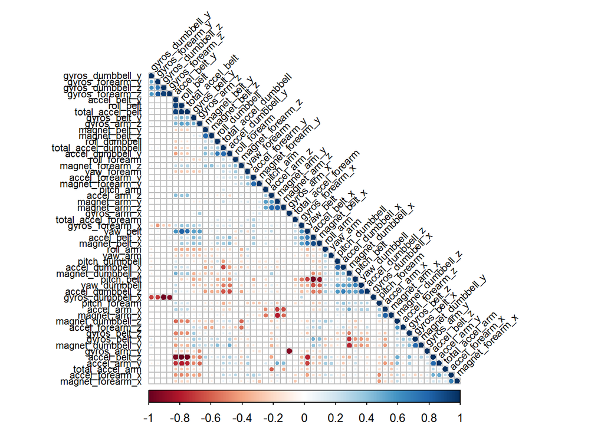

```r
#install.packages("corrplot")
library(corrplot)
tcor <- cor(training[,-lab])
corrplot(tcor, type="lower", order="hclust", tl.col="black",tl.srt=45,  tl.cex = 0.7)#
```

Some of the variables exibit high degree of correlation, therefore it might be useful to consider dropping some of them and therefore reduce the dimensionality of the model. First we want to split the training set into two parts to perform model validation.

## Feature selection

```r
set.seed(777)
inTrain <- createDataPartition(training$classe, p = 0.75, list = FALSE)
train <- training[inTrain, ]
valid <- training[-inTrain, ]
cat("Training:" , dim(train), "Validation:", dim(valid), "\n")
```

```
## Training: 14718 53 Validation: 4904 53
```

Feature selection is performed using Regularized Random Forest. Model tuning is performed to find optimal *mtry* parameter (number of variables considered for splits).

```r
set.seed(777)
flagReg <- 1
tunerrf <- tuneRRF(train[, -lab], train[, lab], stepFactor=1.4, ntreeTry=250, improve=0.01,
                   trace=T, plot=F, doBest=F, flagReg=flagReg)
```

```
## mtry = 7  OOB error = 1.01%
## Searching left ...
## mtry = 5     OOB error = 1.26%
## -0.2567568 0.01
## Searching right ...
## mtry = 9     OOB error = 1.05%
## -0.04054054 0.01
```

```r
tmtry = tunerrf[which.min(tunerrf[,2]),1]
```

Seems like around 7 splits is a good number. Keep in mind that the search is performed on already regularized model, so the optimal number of splits is quite low.

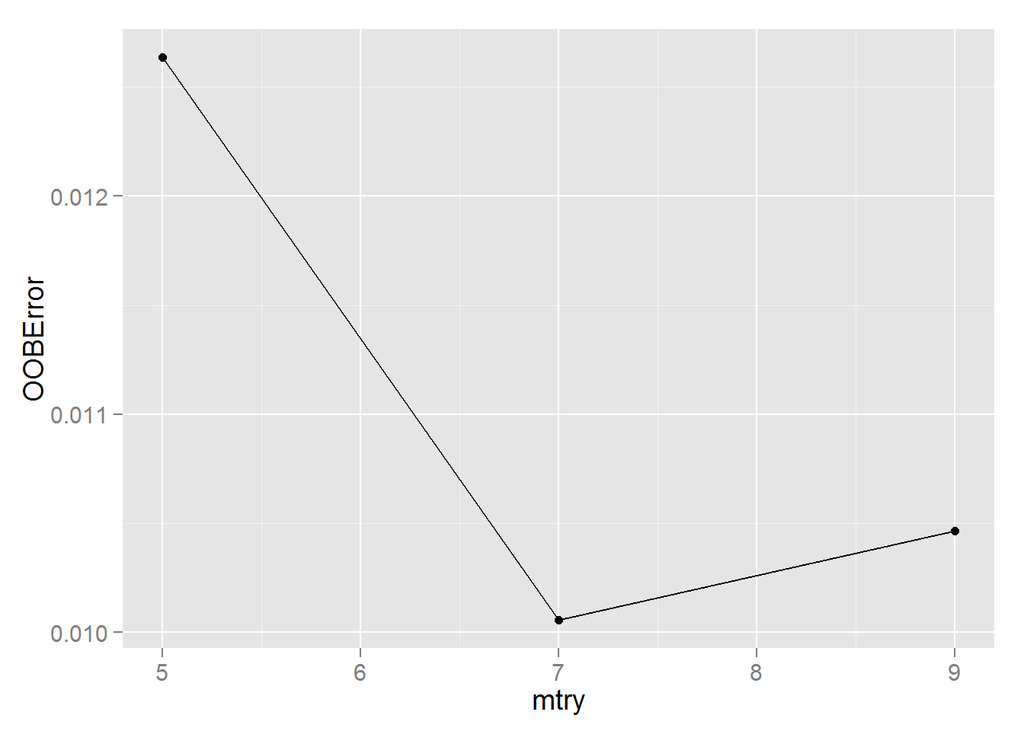

```r
qplot(mtry, OOBError, data=as.data.frame(tunerrf), geom = c("point", "path"))+ theme_grey(base_size = 14)
```

Lets assess performance of regularized model and calculate variable importance

```r
rrfmod1 <- RRF(train[, -lab], train[, lab], ntree=500, mtry = tmtry,
               importance = T, localImp=F, flagReg=flagReg, coefReg = 0.8)
predrrf1 <- predict(rrfmod1, valid[,-lab], type="class")
aa1 <- confusionMatrix(predrrf1, valid[, lab])$overall['Accuracy']
cat("Model accuracy", aa1) #, mean(aa1, aa2))
```

```
## Model accuracy 0.9896003
```

The following chart illustrates suggested variables and their importance

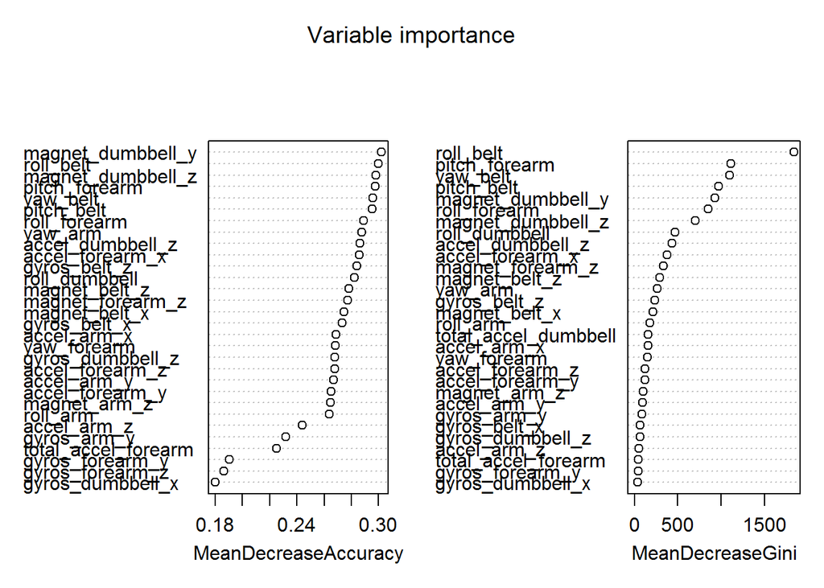

```r
RRF::varImpPlot(rrfmod1, main = "Variable importance")
```

These 31 variables will be used in further analysis, the rest of the independent variables will be dropped.

```r
impRF1 <- rrfmod1$importance
vars1 <- rownames(impRF1)
vimp1 <- data.frame(vars1, impRF1, row.names = NULL)
MDG1<- as.character(vimp1[vimp1$MeanDecreaseGini>0 & order(vimp1$MeanDecreaseGini, decreasing = T), "vars1"])
#cat("Selected variables:", paste(MDG1, collapse = ", "))
training <- training[, c(MDG1, "classe")]
testing <- testing[, c(MDG1, "problem_id")]
lab <- ncol(training)
```

## Model training using parallelized 5-fold cross-validation

In order to develop the cross-validated model the generic function was developed, which allows adding various ML models at will. Cross-validation was performed using the following models: - Random Forest (using `randomForest` package) - RBF support vector machine (using `e1071` package) - C5.0 mixed model (using `C50` package) - Multi-class gbm model (using `gbm` package) - Regularized Random Forest, which will attempt further reduction in the dimensionality (using `RRF` package) - k-Nearest Neighbors (kNN) model (using `class` package) - Bagging Classification Tree model (using `ipred` package)

```r
fitMod <- function(xtrain, ytrain, xtest, ytest, method){
  #returns prediction vector
  if (method=="rf"){
    require(randomForest, quietly=T)
    fit <- randomForest(x=xtrain, y=ytrain, mtry=tmtry)
    pred  <- predict(fit, newdata=xtest)

  }else if(method=="svm"){
    require(e1071, quietly=T)
    fit <- svm(x=xtrain, y=ytrain, probability = FALSE)
    pred <- predict(fit, xtest)

  }else if(method=="earth"){
    require(earth, quietly=T)
    fit <- earth(x=xtrain, y=ytrain) # build model
    pred <- as.numeric(predict(fit, newdata = xtest, type = "class"))

  }else if(method=="C50"){
    require(C50, quietly=T)
    fit <- C5.0(x=xtrain, y=ytrain) # build model
    pred <- predict(fit, newdata = xtest, type = "class")

  }else if(method=="RRF"){
    require(RRF, quietly=T)
    fit <- RRF(x=xtrain, y=ytrain, mtry=tmtry, flagReg=flagReg, coefReg = 0.8)
    pred  <- predict(fit, newdata=xtest, type = "class")

  }else if(method=="gbm"){
    require(gbm, quietly=T)
    fit <- gbm.fit(x=xtrain, y=ytrain, distribution ="multinomial", interaction.depth=6, shrinkage=0.1, n.trees=40, verbose = FALSE)
    p <- predict(fit, newdata=xtest, n.trees=40, type="response")
    pred <- factor(apply(p, 1, which.max), levels=c(1:5), labels = c("A", "B", "C", "D", "E"))

  }else if(method=="knn"){
    require(class, quietly=T)
    pred <- knn(train =xtrain, test = xtest, cl= ytrain) # build model

  }else if(method=="ipred"){
    require(ipred, quietly=T)
    train <- cbind(xtrain, classe=ytrain)
    fit <- bagging(classe~., data=train) # build model
    pred <- predict(fit, newdata = xtest, type="class")

  }else{
    cat("Unknown method! Aborting")
    pred <- NA
  }

  names(pred) <- method
  #  cat("Accuracy of ", method, " for this fold is:", confusionMatrix(as.numeric(pred), as.numeric(ytest))$overall['Accuracy'], "\n")
  return(pred)
}
```

Cross-validation was done using parallelized procedure (utilizing `foreach` and `doParallel` packages) on a cluster with 8 cores. There is also a need to re-assemble the training set to match the order of the cv folds.

```r
k <-5
set.seed(777)
folds <- createFolds(training[, lab], k = k, list = FALSE)
pred.df <- NULL
models <- c("rf", "svm", "C50", "gbm", "RRF", "knn", "ipred")
library(foreach)
library(doParallel)
cl <- makeCluster(8)
registerDoParallel(cl)
pred.df <- foreach(i = 1:k, .packages=c("caret"), .combine = rbind) %dopar% {
           sapply(models, function(x){
                       cat("Fitting ", x, " model \n")
                       fitMod(xtrain=training[folds!=i,-lab], ytrain=training[folds!=i,lab],
                              xtest=training[folds==i,-lab],  ytest= training[folds==i,lab], method = x)})
       } # end of foreach
pred.df <- as.data.frame(pred.df)

train.cv <- NULL
for (n in 1:k){
  train.cv <- rbind(train.cv, training[folds==n,])
}
rownames(train.cv) <- NULL
rownames(pred.df) <- NULL
```

## Ensembling

```r
pred.df$blended <- factor(apply(data.frame(lapply(pred.df, as.numeric), stringsAsFactors=FALSE), 1, function(idx) which.max(tabulate(idx))),
                          levels=c(1:5), labels=c("A", "B", "C", "D", "E"))
err <- NULL
for (i in 1:(ncol(pred.df))){
  e <- data.frame(model=names(pred.df)[i], value= confusionMatrix(pred.df[,i], train.cv$classe)$overall['Accuracy'], stringsAsFactors = FALSE)
  err <- rbind(err, e)
  cat("CV accuracy of", e$model, "is", as.character(e$value), "\n")
}
```

```
## CV accuracy of rf is 0.995973906839262
## CV accuracy of svm is 0.937672000815411
## CV accuracy of C50 is 0.970033635715014
## CV accuracy of gbm is 0.939506676179798
## CV accuracy of RRF is 0.990520843950668
## CV accuracy of knn is 0.978850270104984
## CV accuracy of ipred is 0.987768830904087
## CV accuracy of blended is 0.993833452247477
```

As one can see, performance of blended model is not better than the best performing algorithm (Random Forest). The true power of ensembling is unlocked through stacking. We will now perform model stacking using the 5-fold cross-validated `gbm` model (reusing the same folds we created in the previous step).

```r
# making the CV stacking model
straining <- data.frame(pred.df,train.cv)
slab <- ncol(straining)
set.seed(777)
k=5

spred.v <- NULL
ytest <- NULL
for (i in 1:k){
stackedpred <- fitMod(xtrain=straining[folds!=i,-slab], ytrain=straining[folds!=i,slab], xtest=straining[folds==i,-slab],  ytest= straining[folds==i,slab], method = "gbm")
spred.v <- c(spred.v, stackedpred)
ytest <-c(ytest, straining[folds==i,slab])
}
spred.v <- factor(spred.v, levels=c(1:5), labels=c("A", "B", "C", "D", "E"))
ytest <- factor(ytest, levels=c(1:5), labels=c("A", "B", "C", "D", "E"))

#stacked prediction accuracy
cat("CV accuracy of stacked model\n")
```

```
## CV accuracy of stacked model
```

```r
confusionMatrix(spred.v, ytest)
```

```
## Confusion Matrix and Statistics
##
##           Reference
## Prediction    A    B    C    D    E
##          A 5576   11    0    0    1
##          B    3 3782   13    0    0
##          C    0    4 3400   18    1
##          D    0    0    9 3193    8
##          E    1    0    0    5 3597
##
## Overall Statistics
##
##                Accuracy : 0.9962
##                  95% CI : (0.9953, 0.997)
##     No Information Rate : 0.2844
##     P-Value [Acc > NIR] : < 2.2e-16
##
##                   Kappa : 0.9952
##  Mcnemar's Test P-Value : NA
##
## Statistics by Class:
##
##                      Class: A Class: B Class: C Class: D Class: E
## Sensitivity            0.9993   0.9960   0.9936   0.9928   0.9972
## Specificity            0.9991   0.9990   0.9986   0.9990   0.9996
## Pos Pred Value         0.9979   0.9958   0.9933   0.9947   0.9983
## Neg Pred Value         0.9997   0.9991   0.9986   0.9986   0.9994
## Prevalence             0.2844   0.1935   0.1744   0.1639   0.1838
## Detection Rate         0.2842   0.1927   0.1733   0.1627   0.1833
## Detection Prevalence   0.2848   0.1936   0.1744   0.1636   0.1836
## Balanced Accuracy      0.9992   0.9975   0.9961   0.9959   0.9984
```

Out-of-sample performance of the stacked model on the 5-fold CV is inidicative of performance of the same model on the testing set (to be done in the next step). Stacking allows to sqeeze additional accuracy decimals from already well-performing bag of models.

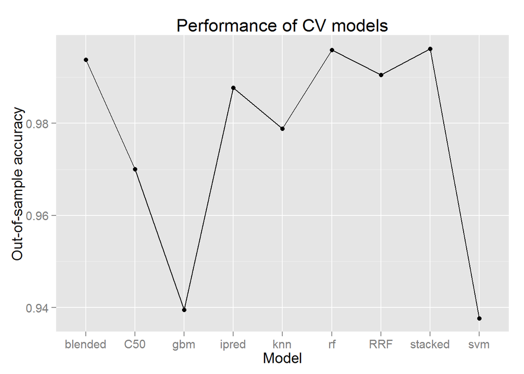

```r
e <- data.frame(model="stacked", value= confusionMatrix(spred.v, ytest)$overall['Accuracy'], stringsAsFactors = FALSE)
err <- rbind(err, e)
ggplot(data=err, aes(x=model, y=value, group=1)) + theme_grey(base_size = 14) +
    geom_line() +
    geom_point() +
    xlab("Model") + ylab("Out-of-sample accuracy") +
    ggtitle("Performance of CV models")
```

```r
#stacked model is what we go for!
```

## Final predictions on the testing set

Now we are ready to perform prediction on the test set. The whole training set will be used for training the same models. The results will be again, blended and stacked.

```r
# making prediction on test set
test.df <- sapply(models, function(x){
  cat("Fitting ", x, " model \n")
  fitMod(xtrain=training[,-lab], ytrain=training[,lab], xtest=testing[,-lab],  ytest= NULL, method = x)})
```

```
## Fitting  rf  model
```

```
## Fitting  svm  model
## Fitting  C50  model
## Fitting  gbm  model
## Fitting  RRF  model
## Fitting  knn  model
## Fitting  ipred  model
```

```r
rownames(test.df) <- NULL

test.df <- as.data.frame(test.df)
test.df$blended <- factor(apply(data.frame(lapply(test.df, as.numeric), stringsAsFactors=FALSE), 1, function(idx) which.max(tabulate(idx))),
                          levels=c(1:5), labels=c("A", "B", "C", "D", "E"))
stesting <- data.frame(test.df,testing)
tlab <- ncol(stesting)
```

Fitting the final stacked model and preparing the submission files.

```r
set.seed(777)
#making prediction on the stacked model
finalpred <- fitMod(xtrain=straining[ ,-slab], ytrain=straining[,slab], xtest=stesting[,-tlab],  ytest= NULL, method = "gbm")

answers <- as.character(finalpred)
pml_write_files = function(x){
  n = length(x)
  for(i in 1:n){
    filename = paste0("problem_id_",i,".txt")
    write.table(x[i],file=filename,quote=FALSE,row.names=FALSE,col.names=FALSE)
  }
}
pml_write_files(answers)
```

Finally, the stacked cross-validated model was applied to the testing set that consists of 20 observations that were not used during the training neither validation. Results are submitted for grading.